# R Notebook

## Lattice

```r
library(lattice)
library(mlmRev)
```

The following dataset records information on students appearing in the 1997 A-level chemistry examination in Britain:

```r
df <- mlmRev::Chem97

head(df)
```

|  | lea | school | student | score | gender | age | gcsescore | gcsecnt |
| --- | --- | --- | --- | --- | --- | --- | --- | --- |
| 1 | 1 | 1 | 1 | 4 | F | 3 | 6.625 | 0.3393157 |
| 2 | 1 | 1 | 2 | 10 | F | -3 | 7.625 | 1.3393157 |
| 3 | 1 | 1 | 3 | 10 | F | -4 | 7.250 | 0.9643157 |
| 4 | 1 | 1 | 4 | 10 | F | -2 | 7.500 | 1.2143157 |
| 5 | 1 | 1 | 5 | 8 | F | -1 | 6.444 | 0.1583157 |
| 6 | 1 | 1 | 6 | 10 | F | 4 | 7.750 | 1.4643157 |

We are interested in the following variables:

-`gcsescore`: average score in GCSE exams (may be used as a predictor)

-`gender`

Let’s try to draw an histogram with `Lattice`:

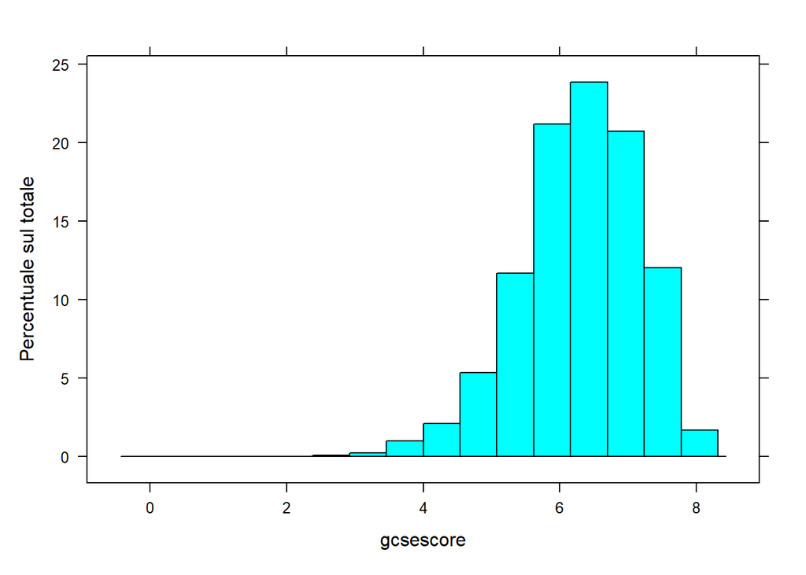

```r
histogram(~ gcsescore, data = df)
```

We would like to display the distribution of `gcsescore` compared across different subgroups, such as those defined by `score`

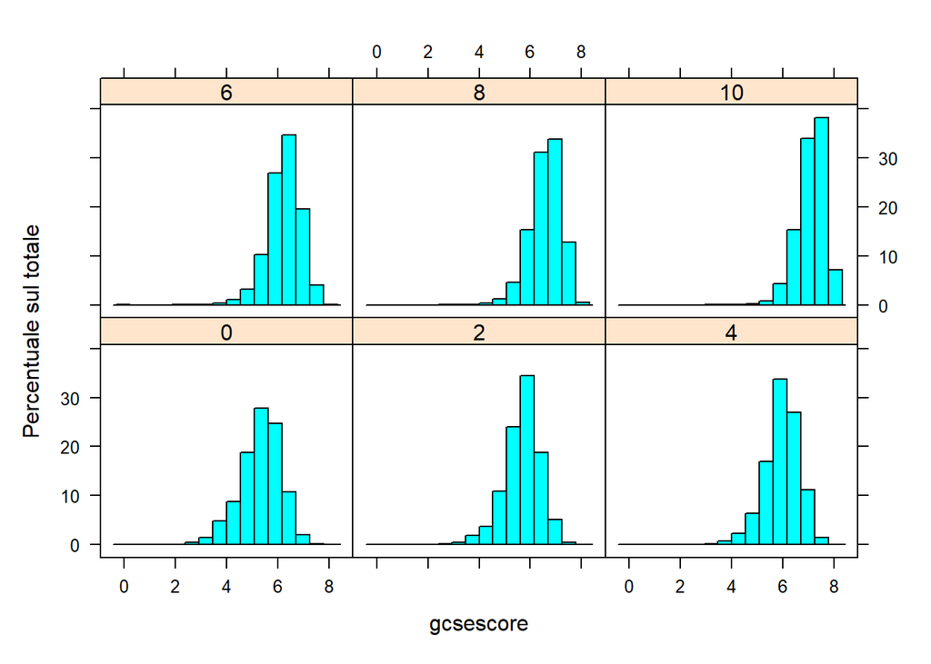

```r
histogram(~ gcsescore | factor(score), data = df)
```

We could also subdivide the `gcsescore` values by `gender`:

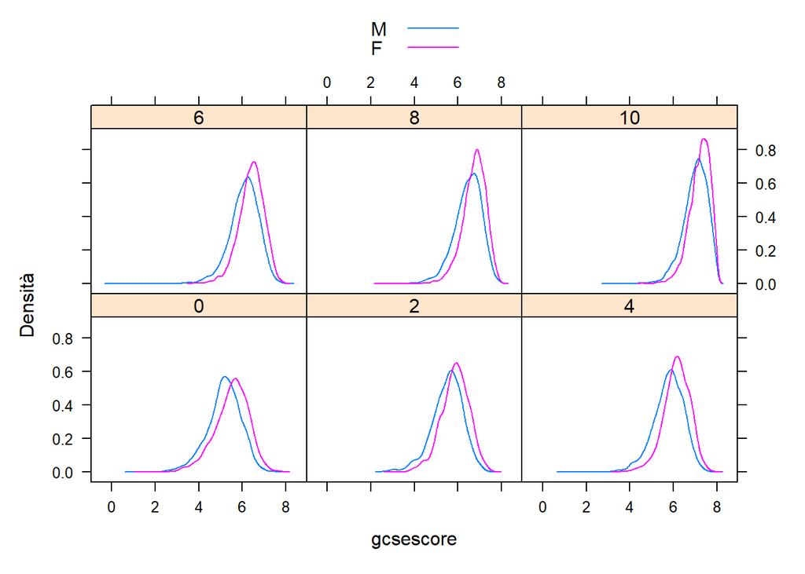

```r
densityplot(~ gcsescore | factor(score), df, groups = gender, plot.points = F, auto.key = T)
```

## Available display types in `lattice`

- `histogram()`
- `densityplot()` : Kernel Density Plot
- `qqmath()` : Theoretical Quantile Plot

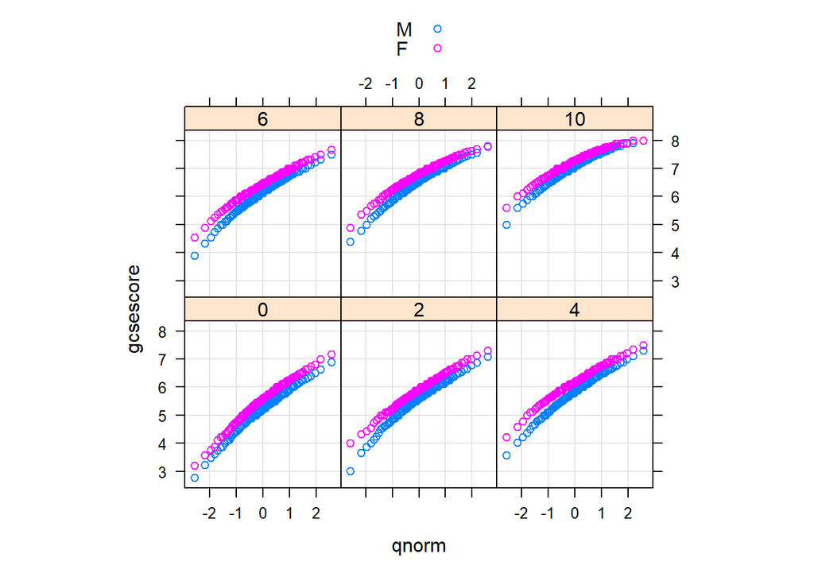

```r
qqmath(~ gcsescore | factor(score), df, groups = gender, f.value = ppoints(100), auto.key = T, type = c('p', 'g'), aspect = 'xy')
```

- `qq()` : Two-sample Quantile Plot

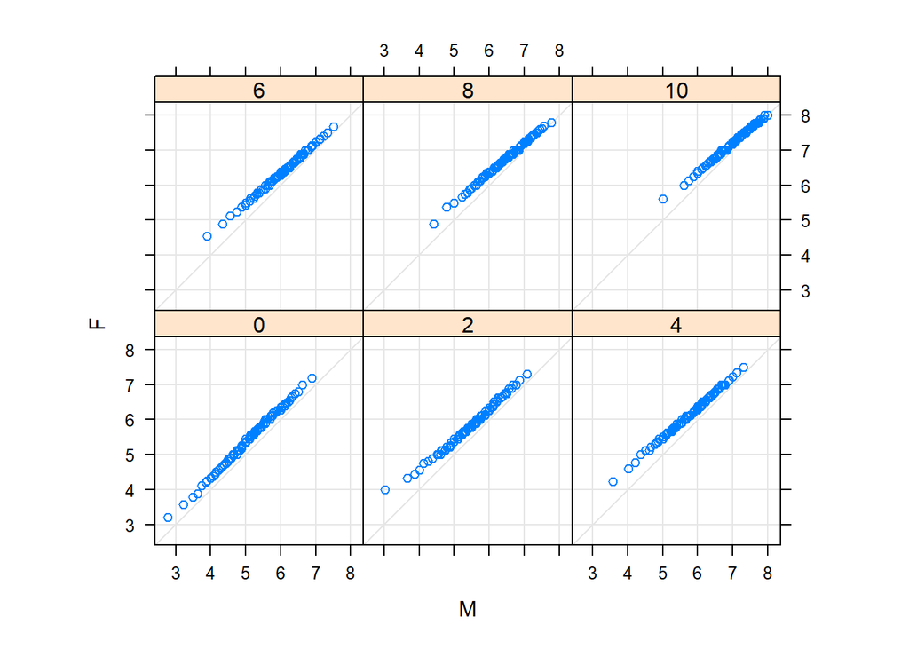

```r
qq(gender ~ gcsescore | factor(score), df, f.value = ppoints(100), type = c('p', 'g'), aspect = 1)
```

- `stripplot()` : Stripchart (Comparative 1D Scatter plots)

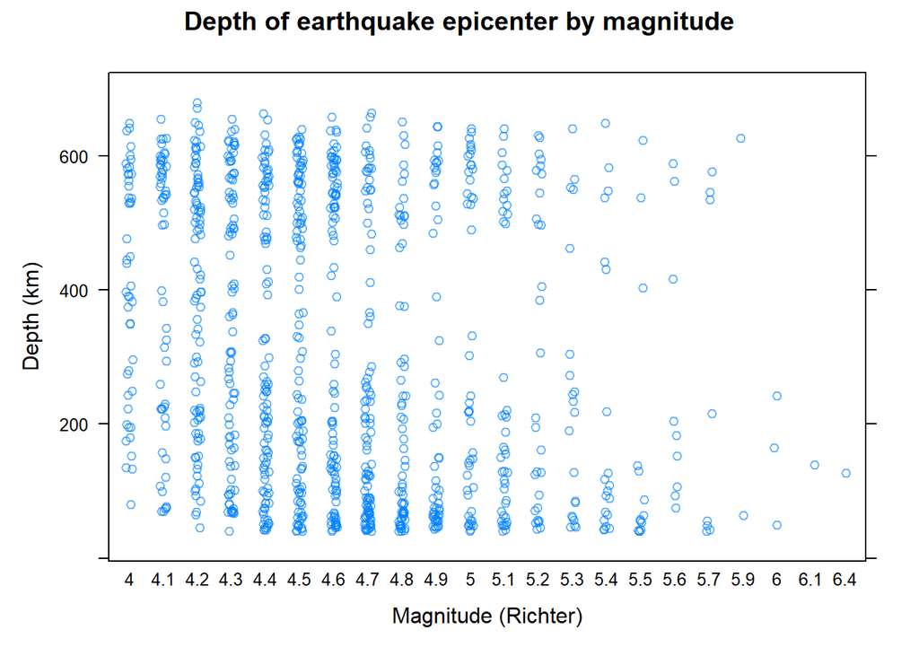

```r
stripplot(depth ~ factor(mag), data = quakes, jitter.data = T, alpha = 0.6, main = 'Depth of earthquake epicenter by magnitude', xlab = 'Magnitude (Richter)', ylab = 'Depth (km)')
```

- `bwplot()` : Comparative Box-and-Whisker Plots

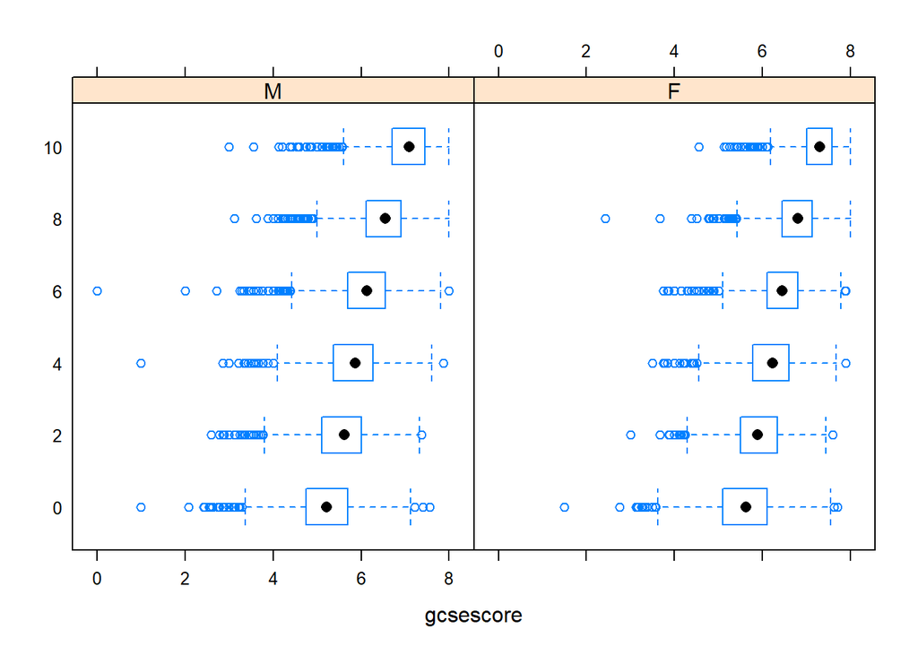

```r
bwplot(factor(score) ~ gcsescore | gender, df)
```

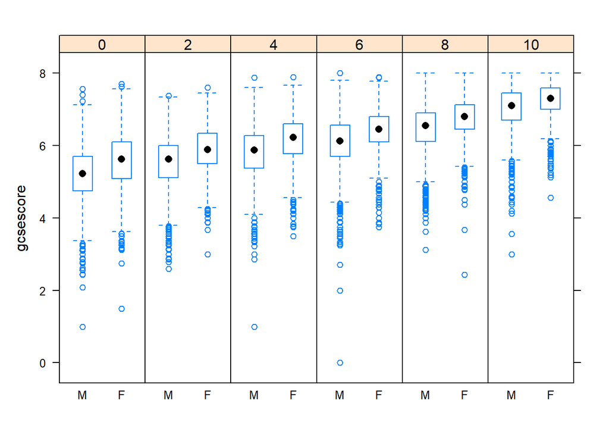

```r
bwplot(gcsescore ~ gender | factor(score), df, layout = c(6, 1))
```

- `barchart()`

```r
VADeathsDF <- as.data.frame.table(VADeaths, responseName = 'Rate')

VADeathsDF
```

| Var1 | Var2 | Rate |
| --- | --- | --- |
| 50-54 | Rural Male | 11.7 |
| 55-59 | Rural Male | 18.1 |
| 60-64 | Rural Male | 26.9 |
| 65-69 | Rural Male | 41.0 |
| 70-74 | Rural Male | 66.0 |
| 50-54 | Rural Female | 8.7 |
| 55-59 | Rural Female | 11.7 |
| 60-64 | Rural Female | 20.3 |
| 65-69 | Rural Female | 30.9 |
| 70-74 | Rural Female | 54.3 |

[output cut: 10 more lines]

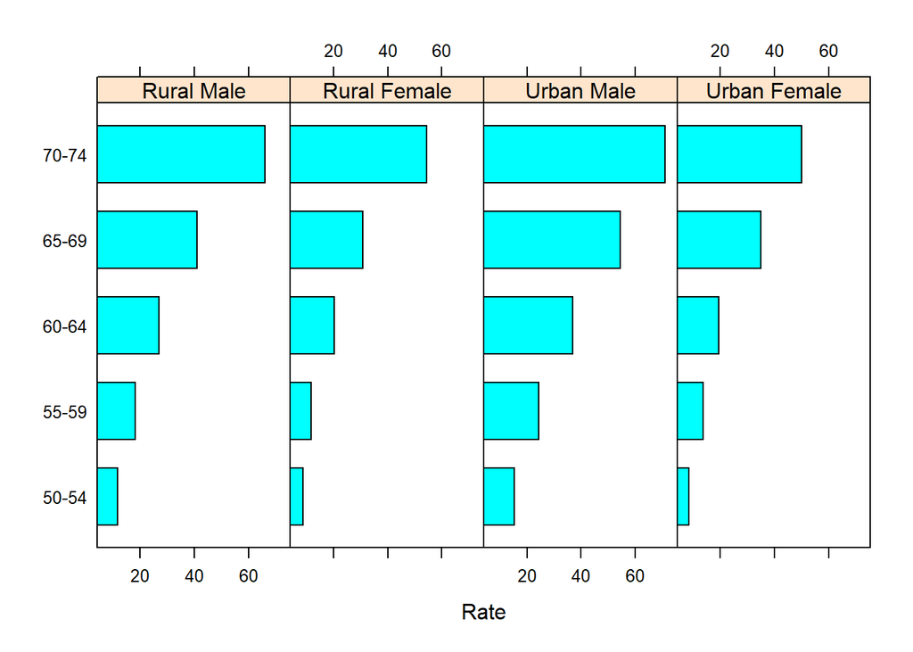

```r
barchart(Var1 ~ Rate | Var2, VADeathsDF, layout = c(4, 1))
```

We can set the origin to 0:

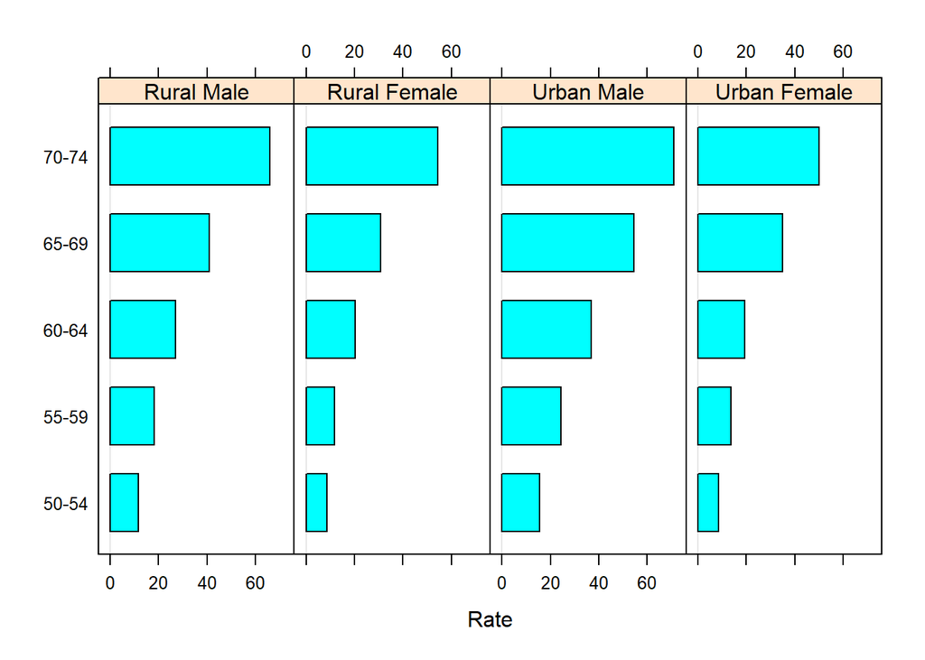

```r
barchart(Var1 ~ Rate | Var2, VADeathsDF, layout = c(4, 1), origin = 0)
```

- `dotplot()`

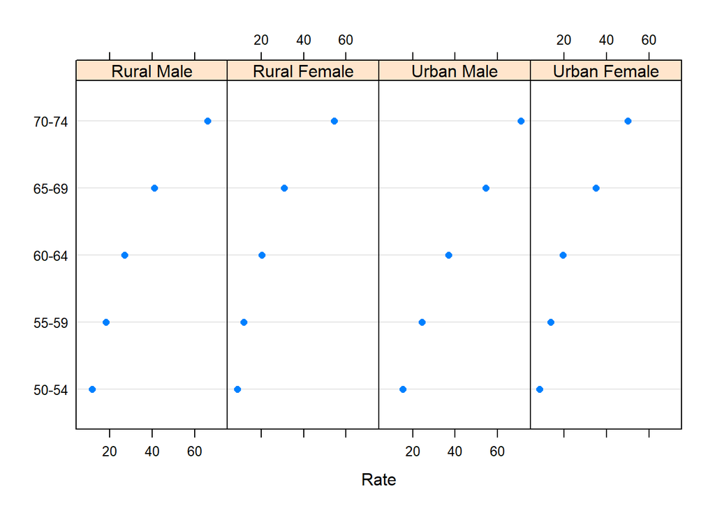

```r
dotplot(Var1 ~ Rate | Var2, VADeathsDF, layout = c(4, 1))
```

We can use Var2 as a grouping variable:

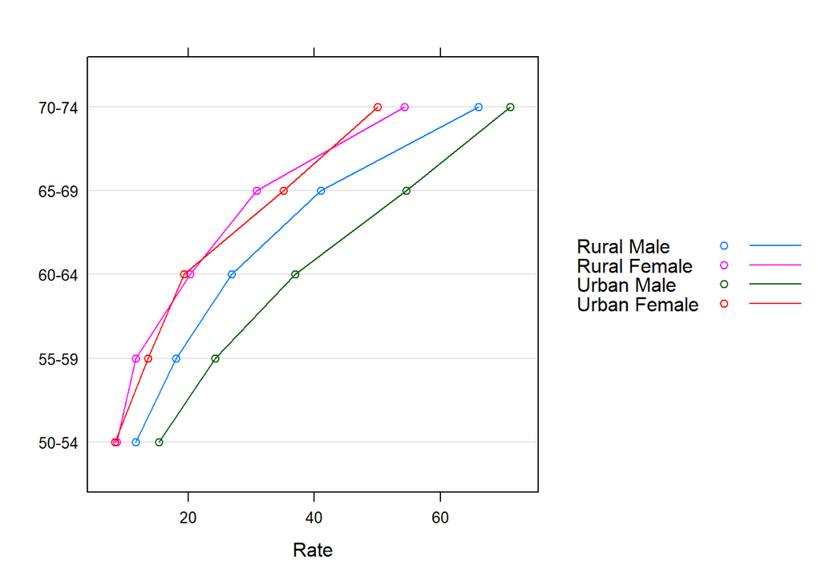

```r
dotplot(Var1 ~ Rate, data = VADeathsDF, groups = Var2, type = 'o', auto.key = list(space = 'right', points = T, lines = T))
```

The following one produces the same as before:

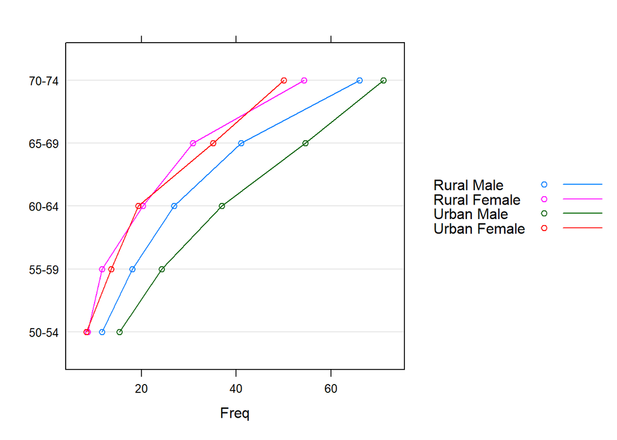

```r
dotplot(VADeaths, type = 'o', auto.key = list(points = T, lines = T, space = 'right'))
```

- `xyplot()` : Scatter Plot

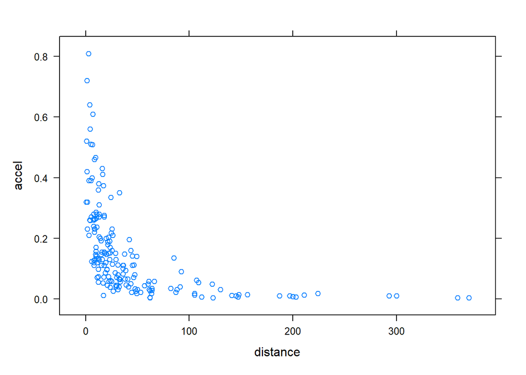

```r
data(Earthquake, package = 'nlme')

xyplot(accel ~ distance, data = Earthquake)
```

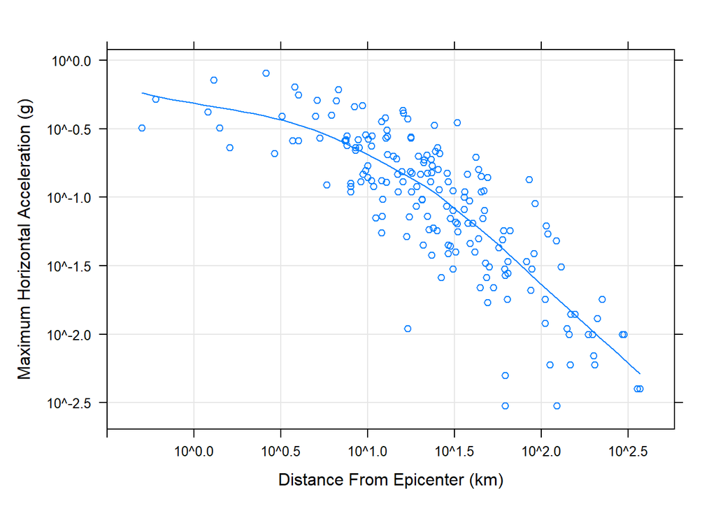

```r
xyplot(accel ~ distance, data = Earthquake, scales = list(log = T), type =c('p', 'g', 'smooth'), xlab = 'Distance From Epicenter (km)', ylab = 'Maximum Horizontal Acceleration (g)')
```

```r
Depth <- equal.count(quakes$depth, number = 8, overlap = .1)
summary(Depth)
```

```
##
## Intervalli:
##     min   max count
## 1  39.5  63.5   138
## 2  60.5 102.5   138
## 3  97.5 175.5   138
## 4 161.5 249.5   142
## 5 242.5 460.5   138
## 6 421.5 543.5   137
## 7 537.5 590.5   140
## 8 586.5 680.5   137
##
## Sovrapposizione tra intervalli adiacenti:
## [1] 16 14 19 15 14 15 15
```

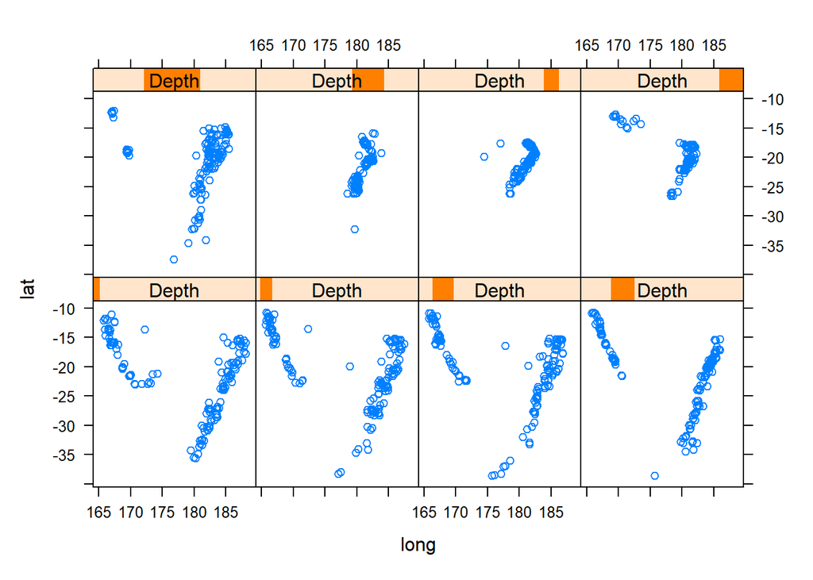

```r
xyplot(lat ~ long | Depth, data = quakes)
```

- `cloud()` : 3D Scatter Plot

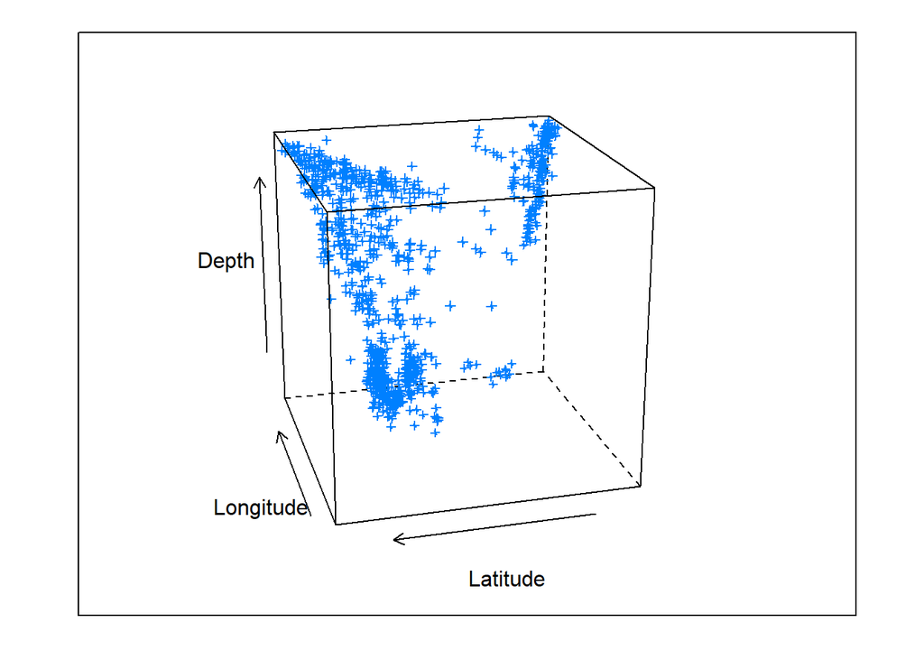

```r
cloud(depth ~ lat * long, data = quakes,
      zlim = rev(range(quakes$depth)),
      screen = list(z = 105, x = -70), panel.aspect = 0.75,
      xlab = 'Longitude', ylab = 'Latitude', zlab = 'Depth')
```

- `splom()` : Scatter Plot Matrix
- `contourplot()` : Contour Plot of Surfaces
- `levelplot()` : False Color Level Plot of Surfaces
- `wireframe()` : 3D Perspective Plot of Surfaces
- `parallel()` : Parallel Coordinates Plot

## The trellis object

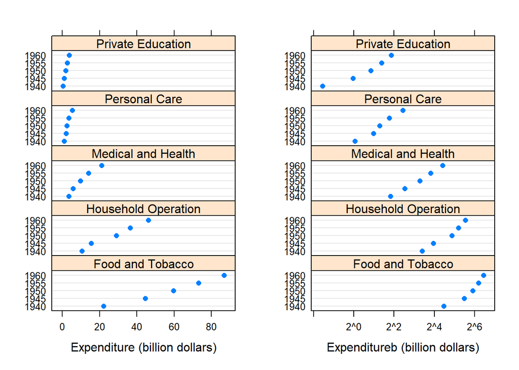

```r
dp.uspe <- dotplot(t(USPersonalExpenditure), groups = F, layout = c(1, 5),
                   xlab = 'Expenditure (billion dollars)')

dp.uspe.log <- dotplot(t(USPersonalExpenditure), groups = F, layout = c(1, 5),
                       scales = list(x = list(log = 2)),
                       xlab = 'Expenditureb (billion dollars)')

plot(dp.uspe, split = c(1, 1, 2, 1))

plot(dp.uspe.log, split = c(2, 1, 2, 1), newpage = F)
```

## Some Example

Italy is importing an item A from 5 other countries (US, UK, Russia, China, Brazil). In the last 300 months (Jan 1994 - Dec 2018), the imported QUANTITIES are:

```r
set.seed(42)
from_us <- rnorm(300, 500, 50)
from_uk <- rnorm(300, 200, 20)
from_ru <- rnorm(300, 1000, 75)
from_cn <- rnorm(300, 800, 10)
from_br <- rnorm(300, 300, 40)
```

The import PRICE has changed throughout the years as follows:

```r
set.seed(42)
price_from_us <- seq(from = 1.1, to = 2.5, length.out = 300)
price_from_uk <- seq(from = 1.5, to = 2.0, length.out = 300)
price_from_ru <- seq(from = 0.7, to = 2.0, length.out = 300)
price_from_cn <- seq(from = 0.2, to = 4.0, length.out = 300)
price_from_br <- seq(from = 0.5, to = 1.2, length.out = 300)
```

Let’s build a dataframe from this data:

```r
imports <- data.frame(month = format(seq(as.Date("1994/01/01"), by = 'month', length.out = 300), "%m %Y"),
                      quantity = c(from_us, from_uk, from_ru, from_cn, from_br),
                      price = c(price_from_us, price_from_uk, price_from_ru, price_from_cn, price_from_br),
                      country = as.factor(c(rep('us', 300), rep('uk', 300), rep('ru', 300), rep('cn', 300), rep('br', 300))))
```

and add the total_cost column:

```r
imports$total_cost <- imports$quantity * imports$price
```

let’s also see the range of the quantity:

```r
range(imports$quantity)
```

```
## [1]  150.7733 1240.8399
```

let’s initialzie an `xyplot()` with x going from 0 to 300 (300 months) and y from 0 to 1300 (max quantity is 1240):

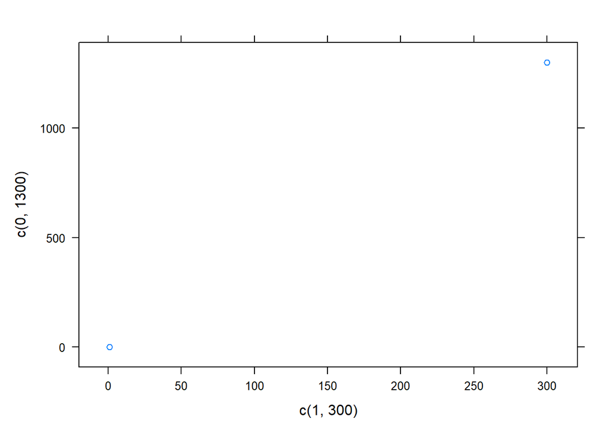

```r
library(lattice)

xyplot(c(0, 1300) ~ c(1, 300))
```

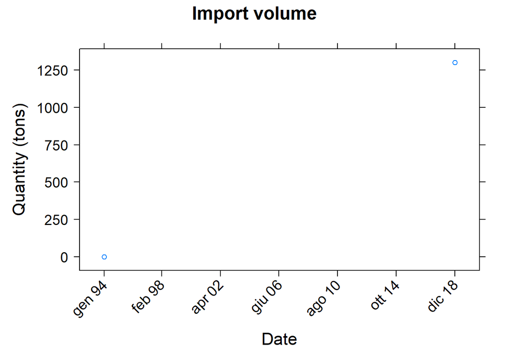

```r
convert_dates <- function(month){
  return(format(as.Date(paste('01', month, sep = ' '), format = '%d %m %Y'), '%b %y'))
}

xyplot(c(0, 1300) ~ c(1, 300),
       main = list(label = 'Import volume', cex = 1.5),                                          #Main title label and expansion factor
       xlab = list(label = 'Date', cex = 1.4),                                                   #Xlab label and expansion factor
       ylab = list(label = 'Quantity (tons)', cex = 1.4),                                        #Ylab label and expansion factor
       scales = list(x = list(at = c(1, seq(50, 300, by = 50)),                                  #Set ticks for x : [1, 50, 100, 150, 200, 250, 300]
                              label = convert_dates(imports$month[c(1, seq(50, 300, by = 50))]), #To positions defined in at, we give labels converting months with previous function
                              rot = 45, cex = 1.2),                                              #Also we rotate by 45° and with expansion factor of 1.2
                     y = list(at = seq(0, 1300, by = 250), cex = 1.2)))                          #Set ticks for y : [0, 250, 500, 750, 1000, 1250]
```

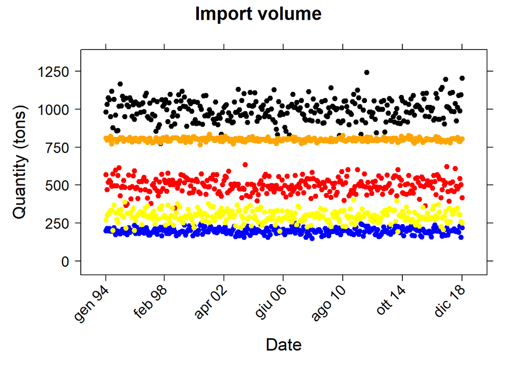

```r
#Let's also plot the data

mycols <- c('red', 'blue', 'black', 'orange', 'yellow')
names(mycols) <- unique(imports$country)                #associate to each color a country name

xyplot(c(0, 1300) ~ c(1, 300),
       main = list(label = 'Import volume', cex = 1.5),
       xlab = list(label = 'Date', cex = 1.4),
       ylab = list(label = 'Quantity (tons)', cex = 1.4),
       scales = list(
         x = list(at = c(1, seq(50, 300, by = 50)),
             label = convert_dates(imports$month[c(1, seq(50, 300, by = 50))]),
             rot = 45, cex = 1.2),
         y = list(at = seq(0, 1300, by = 250), cex = 1.2)
         ),
       panel=function(...){                                                                                 #panel=function(...) structure plot in a lattice element
         for(i in unique(imports$country)){                                                                 #for all the 5 countries
           lpoints(1:300, imports$quantity[imports$country == i], type = 'p', pch = 19, col = mycols[i])    #plot a scatterplot, where x is a progression from 1 to 300 and y is equal to the quantity corresponding to that particular country
         }                                                                                                  #Also, with p we plot just points, pch=19 is the type of points to use, and color taken from mycols list, progressively
        }
       )
```

plot with lines:

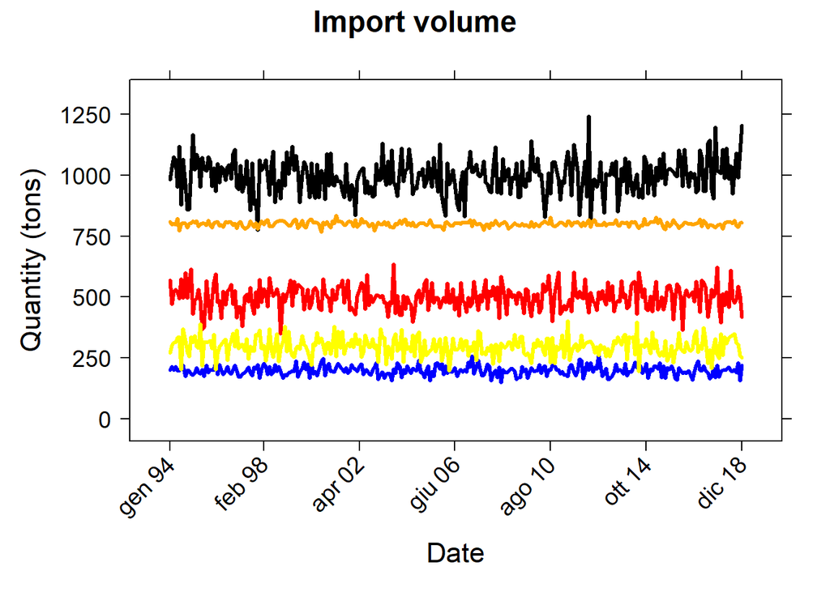

```r
xyplot(c(0, 1300) ~ c(1, 300),
       main = list(label = 'Import volume', cex = 1.5),
       xlab = list(label = 'Date', cex = 1.4),
       ylab = list(label = 'Quantity (tons)', cex = 1.4),
       scales = list(
         x = list(at = c(1, seq(50, 300, by = 50)),
                  label = convert_dates(imports$month[c(1, seq(50, 300, by = 50))]),
                  rot = 45, cex = 1.2),
         y = list(at = seq(0, 1300, by = 250), cex = 1.2)
       ),
       panel=function(...){                                                                                 #panel=function(...) structure plot in a lattice element
         for(i in unique(imports$country)){                                                                 #for all the 5 countries
           lpoints(1:300, imports$quantity[imports$country == i], type = 'l', lwd = 3, col = mycols[i])    #plot a scatterplot, where x is a progression from 1 to 300 and y is equal to the quantity corresponding to that particular country
         }                                                                                                  #Also, with p we plot just points, pch=19 is the type of points to use, and color taken from mycols list, progressively
       }
)
```

Add a legend:

```r
library(Hmisc)
```

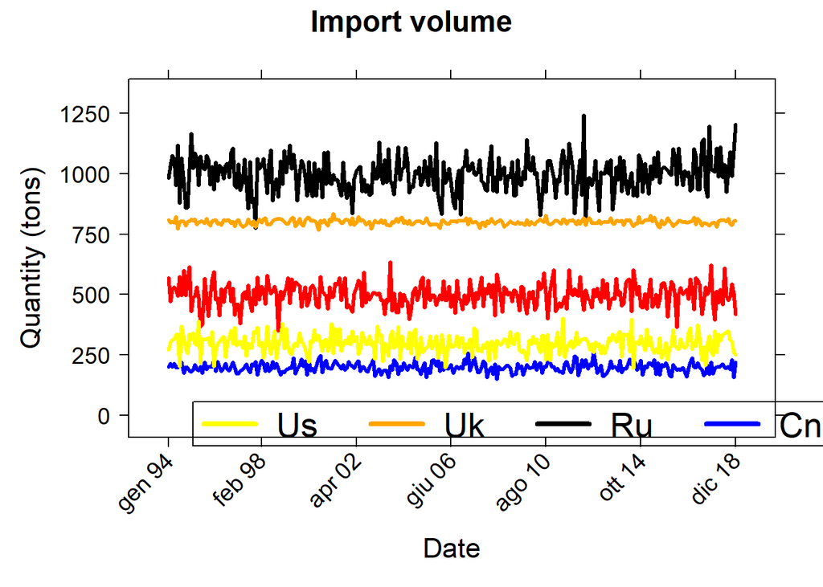

```r
xyplot(c(0, 1300) ~ c(1, 300),
       main = list(label = 'Import volume', cex = 1.5),
       xlab = list(label = 'Date', cex = 1.4),
       ylab = list(label = 'Quantity (tons)', cex = 1.4),
       scales = list(
         x = list(at = c(1, seq(50, 300, by = 50)),
                  label = convert_dates(imports$month[c(1, seq(50, 300, by = 50))]),
                  rot = 45, cex = 1.2),
         y = list(at = seq(0, 1300, by = 250), cex = 1.2)
       ),
       key = list(x = 0.1, y = 0.1,                                                                         #pos of legend x, y
                  lines = list(lwd = 4, col = mycols[unique(imports$country)]),                             #prepares lines of lwd=4 in different colors
                  text = list(label = capitalize(as.character(unique(imports$country))), cex = 1.75),       #add country names near lines. Where names are transformed into characters and capitalized
                  padding.text = 4,                                                                         #add white space around the text
                  border = T,                                                                               #add border around legend's box
                  columns = 5),                                                                             #split legend in 5 columns, one for each country, and one row
       panel=function(...){
         for(i in unique(imports$country)){
           lpoints(1:300, imports$quantity[imports$country == i], type = 'l', lwd = 3, col = mycols[i])
         }
       }
)
```

Now find month with maximal import, using sqldf package to interact with the DF as a database:

```r
library(sqldf)
```

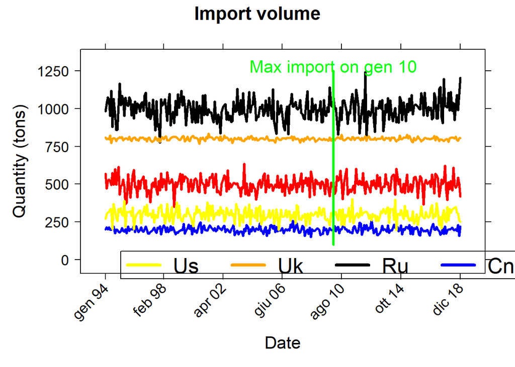

```r
#total quantity for each month
summarised <- sqldf('select month, sum(quantity) as total_quantity from imports group by month') #SQL query to data

mx <- which(summarised$total_quantity == max(summarised$total_quantity), arr.ind = T)            #and find which date is == max of total_quality


#now we add this piece of information to the plot:

xyplot(c(0, 1300) ~ c(1, 300),
       main = list(label = 'Import volume', cex = 1.5),
       xlab = list(label = 'Date', cex = 1.4),
       ylab = list(label = 'Quantity (tons)', cex = 1.4),
       scales = list(
         x = list(at = c(1, seq(50, 300, by = 50)),
                  label = convert_dates(imports$month[c(1, seq(50, 300, by = 50))]),
                  rot = 45, cex = 1.2),
         y = list(at = seq(0, 1300, by = 250), cex = 1.2)
       ),
       key = list(x = 0.1, y = 0.1,
                  lines = list(lwd = 4, col = mycols[unique(imports$country)]),
                  text = list(label = capitalize(as.character(unique(imports$country))), cex = 1.75),
                  padding.text = 4,
                  border = T,
                  columns = 5),
       panel=function(...){
         for(i in unique(imports$country)){
           lpoints(1:300, imports$quantity[imports$country == i], type = 'l', lwd = 3, col = mycols[i])
         }
         lsegments(x0 = mx, y0 = 100, x1 = mx, y1 = 1250, col = 'green', lwd = 3)                                       #segment of which x0 is mx and goes in y from 100 to 1250
         ltext(mx, 1280, col = 'green', label = paste('Max import on', convert_dates(imports$month[mx]), sep = ' '),    #add text with x coord mx and y coord 1280 (just above the end of the segment), with text: 'Max import on' given date
                 cex = 1.4)
       }
)
```

Let’s move on a boxplot

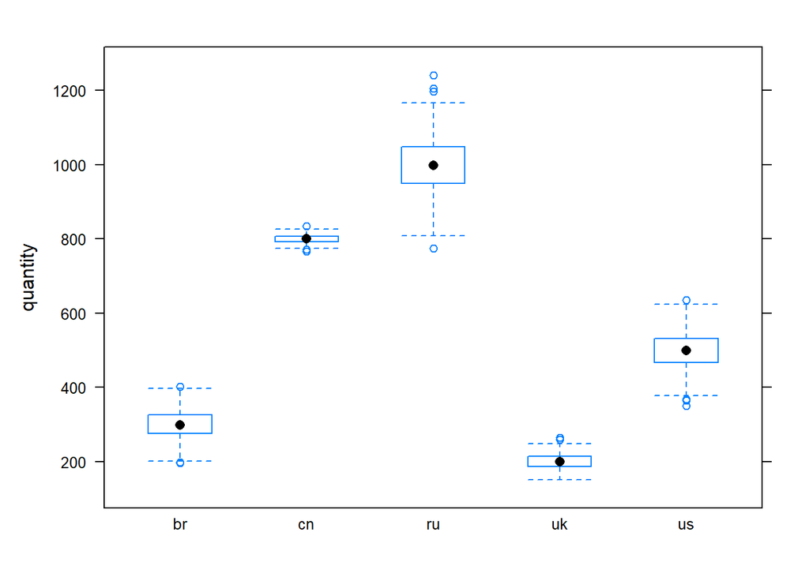

```r
bwplot(quantity ~ country, data = imports)
```

Polish it:

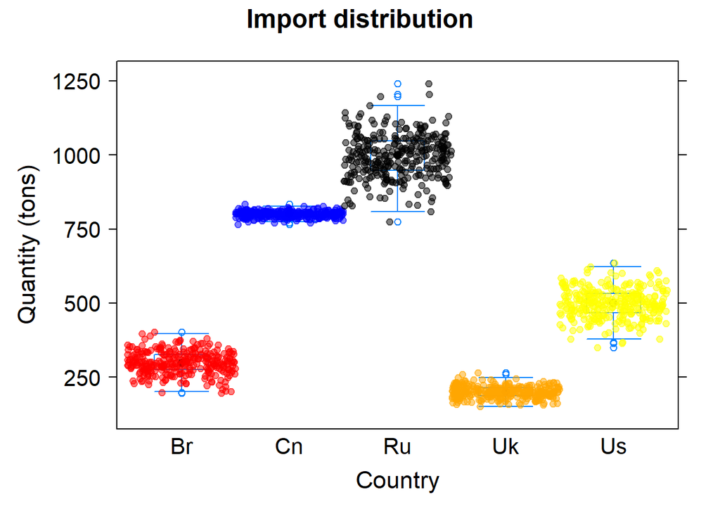

```r
bwplot(imports$quantity ~ imports$country,
       par.settings = list(box.umbrella = list(lty = 1)),
       main = list(label = 'Import distribution', cex = 1.5),
       xlab = list(label = 'Country', cex = 1.4),
       ylab = list(label = 'Quantity (tons)', cex = 1.4),
       scales = list(
         y = list(at = seq(0, 1300, by = 250), cex = 1.3),
         x = list(label = capitalize(as.character(sort(unique(imports$country)))), cex = 1.3)
         ),
         panel  = function(...){
           panel.bwplot(notch = F, ...)                                                                                                                                                                               #bwplot, notch = F to not stack together
           for (i in 1:5){                                                                                                                                                                                            #for each country:
             panel.points(x = jitter(rep(i, 300), amount = .5), imports[imports$country==sort(unique(imports$country))[i], 'quantity'], col = mycols[sort(unique(imports$country))[i]], pch = 19, alpha = 0.5)        #we draw points on the panel, jittering them and take from imports only the quantity column. Finally set colors through mycols vector
           }
         }
       )
```

Let’s put together `xyplot()` and `bwplot()`:

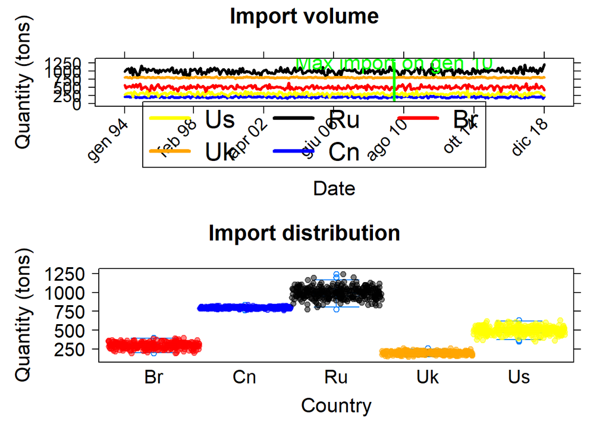

```r
g1 <- xyplot(c(0, 1300) ~ c(1, 300),
             main = list(label = 'Import volume', cex = 1.5),
             xlab = list(label = 'Date', cex = 1.4),
             ylab = list(label = 'Quantity (tons)', cex = 1.4),
             scales = list(
               x = list(at=c(1, seq(50, 300, by = 50)), label = convert_dates(imports$month[c(1, seq(50, 300, by = 50))]), rot = 45, cex = 1.2),
               y = list(at = seq(0, 1300, by = 250), cex = 1.2)
             ),
             key = list(x = 0.1, y = 0.1,
                        lines = list(lwd = 4, col = mycols[unique(imports$country)]),
                        text = list(label = capitalize(as.character(unique(imports$country))), cex = 1.75),
                        padding.text = 4,
                        border = T,
                        columns = 3),
             panel = function(...){
               for (i in unique(imports$country)){
                 lpoints(1:300, imports$quantity[imports$country==i], type = 'l', lwd = 3, col = mycols[i])
               }
               lsegments(x0 = mx, y0 = 100, x1 = mx, y1 = 1250, col = 'green', lwd = 3)
               ltext(mx, 1280, col = 'green', label = paste('Max import on', convert_dates(imports$month[mx]), sep = ' '),
                     cex = 1.4)
               }
             )

g2 <- bwplot(imports$quantity ~ imports$country, par.settings = list(box.umbrella = list(lty = 1)),
             main = list(label = 'Import distribution', cex = 1.5),
             xlab = list(label = 'Country', cex = 1.4),
             ylab = list(label = 'Quantity (tons)', cex = 1.4),
             scales = list(
               y = list(at = seq(0, 1300, by = 250), cex = 1.3),
               x = list(label = capitalize(as.character(sort(unique(imports$country)))), cex = 1.3)
             ),
             panel = function(...){
               panel.bwplot(notch=T,...)
               for (i in 1:5){
                 panel.points(x = jitter(rep(i, 300), amount = 0.5), imports[imports$country == sort(unique(imports$country))[i], 'quantity'], col = mycols[sort(unique(imports$country))[i]], pch = 19, alpha = 0.5)
               }
             }
)


library(gridExtra)

grid.arrange(g1, g2, ncol = 1)
```